# Лабораторна робота № 8. Просторова фільтрація зображень: згладжування, шумозаглушення та підкреслення меж

### Мета: Дослідити математичні засади та алгоритми двовимірної просторової фільтрації на основі операцій згортки та кореляції матриць, вивчити властивості лінійних згладжувальних фільтрів (усереднюючого та Гаусового), опанувати методи нелінійної фільтрації (медіанного та білатерального фільтрів) для селективного придушення імпульсного та флуктуаційного шумів, провести кількісну оцінку якості реставрації за критеріями $\text{MSE}$ та $\text{PSNR}$, а також реалізувати підвищення різкості контурів за допомогою дискретного оператора Лапласа.

#### *Варіант 2 (№ 22 у списку: $22 - 20 = 2$)*

### Виконав: Яцентюк Євгеній, група: КІ-24-1

[**GitHub**](https://github.com/kefir4ikk)

## 1. Імпорт бібліотек та налаштування стилю відображення

```python
import os
import csv
import json
import cv2
import numpy as np
import matplotlib.pyplot as plt
from numpy.lib.stride_tricks import sliding_window_view
from scipy import ndimage

os.makedirs("figures", exist_ok=True)
os.makedirs("data", exist_ok=True)

plt.rcParams['font.family'] = 'DejaVu Sans'
plt.rcParams['axes.edgecolor'] = '#2b2b2b'
plt.rcParams['axes.linewidth'] = 1.0
plt.rcParams['grid.color'] = '#cccccc'
plt.rcParams['grid.linestyle'] = '--'
plt.rcParams['grid.alpha'] = 0.6

import scipy, matplotlib
print(f"NumPy: {np.__version__} | OpenCV: {cv2.__version__} | SciPy: {scipy.__version__} | Matplotlib: {matplotlib.__version__}")
```

```
NumPy: 2.5.4 | OpenCV: 5.0.0 | SciPy: 1.18.1 | Matplotlib: 3.11.2
```

## 2. Параметри варіанта 2 та постановка завдання

**Індивідуальне завдання (варіант 2):**

| СКО шуму $\sigma_g$, В | Щільність $p_{sp}$ | Ядра $K_{box},K_G,K_{med}$ | $\sigma$ Гаусса | Bilateral $(d,\sigma_c,\sigma_s)$ | Вага різкості $k_{sharp}$ |
| --- | --- | --- | --- | --- | --- |
| 25.0 | 0.08 | $5\times5,\ 5\times5,\ 5$ | 1.5 | $d=9,\ \sigma_c=80,\ \sigma_s=80$ | 0.60 |

Усі розрахунки виконуються для 8-бітного монохромного зображення ($L=256$). Тестова сцена — еталонне контрастне зображення $400\times600$ із темним прямокутником, концентричними колами, штриховою текстурою, тонкими променями та текстовим маркером.

**Математичні моделі:**

$$g(x,y)=\sum_{s=-a}^{a}\sum_{t=-a}^{a}f(x+s,y+t)\,h(s,t);\qquad h_{box}=\frac1{K^2};\qquad h_G(s,t)\propto e^{-\frac{s^2+t^2}{2\sigma^2}};\qquad g=\operatorname{median}\{f(x+s,y+t)\}$$

$$g_{bil}(x,y)=\frac1{W_p}\sum f(x+s,y+t)\,e^{-\frac{s^2+t^2}{2\sigma_s^2}}\,e^{-\frac{(f(x+s,y+t)-f(x,y))^2}{2\sigma_r^2}};\qquad \mathrm{MSE}=\overline{(I_{ref}-I_{filt})^2};\qquad \mathrm{PSNR}=10\lg\frac{255^2}{\mathrm{MSE}}.$$

Для підвищення різкості використовується ядро Лапласа 8-зв'язної околиці з додатним центром $+8$ (матриця $[[-1,-1,-1],[-1,8,-1],[-1,-1,-1]]$) і схема $I_{sharp}=I_{orig}+k\cdot I_{lap}$. Це ядро відповідає знаку, протилежному класичному $\nabla^2$ (із центром $-4$ чи $-8$), тому додавання відгуку підсилює контур.

**Що додатково перевіряється в роботі:**

- модель шуму: реальна дисперсія гаусового шуму відрізняється від $\sigma_g^2$ через **відсікання** значень на $[0,255]$ (темні об'єкти $20\ldots40$ при $\sigma_g=25$), тому порівнюється виміряна та теоретично очікувана $\mathrm{MSE}$; для імпульсного шуму — виміряна та теоретична $\mathrm{MSE}$ і точна щільність ураження;
- коректність фільтрів: кожен із чотирьох фільтрів звіряється з незалежною реалізацією (кореляція через `sliding_window_view`, `scipy.ndimage`, прямий розрахунок білатерального ядра);
- розподіл похибки між **однорідними ділянками** та **зоною контурів** — для кількісної перевірки тверджень про збереження меж;
- чутливість до параметрів (розмір ядра, $\sigma$ Гаусса, $\sigma_c$ білатерального);
- вплив підвищення різкості на шум та контури.

Параметр білатерального фільтра $\sigma_s=80$ значно перевищує радіус вікна ($d=9$, радіус 4), тому просторова вага $e^{-(s^2+t^2)/(2\sigma_s^2)}\ge0.9975$ у всьому вікні практично сталa; фільтр фактично зважує пікселі лише за яскравістю ($\sigma_c$). Вікно в OpenCV має круглу форму (відстань від центру $\le4$).

```python
# --- Параметри варіанта 2
SIGMA_G, P_SP = 25.0, 0.08
K_BOX, K_GAUSS, K_MED = 5, 5, 5
SIGMA_GAUSS = 1.5
BIL_D, BIL_SIGMA_C, BIL_SIGMA_S = 9, 80, 80
K_SHARP = 0.60
H_IMG, W_IMG = 400, 600

def generate_reference_scene(height=H_IMG, width=W_IMG):
    """Еталонне контрастне зображення: фігури, штрихова текстура, тонкі промені, текст."""
    img = np.full((height, width), 200, dtype=np.uint8)
    cv2.rectangle(img, (50, 50), (220, 220), 40, -1)                                   # темний прямокутник
    cv2.circle(img, (420, 140), 90, 30, -1); cv2.circle(img, (420, 140), 60, 140, -1); cv2.circle(img, (420, 140), 30, 240, -1)
    for x in range(60, 210, 10):                                                       # штрихова текстура
        cv2.line(img, (x, 260), (x, 360), 20, 2)
    for angle in np.linspace(0, np.pi, 9):                                             # тонкі промені
        cv2.line(img, (420, 300), (int(420 + 90 * np.cos(angle)), int(300 + 90 * np.sin(angle))), 50, 2)
    cv2.putText(img, "SPATIAL FILTERING", (230, 230), cv2.FONT_HERSHEY_SIMPLEX, 0.8, 20, 2, cv2.LINE_AA)
    return img

img_clean = generate_reference_scene()
assert cv2.imwrite("data/reference_pattern.png", img_clean)
print(f"Еталонне зображення збережено: data/reference_pattern.png ({img_clean.shape[0]}x{img_clean.shape[1]}, {img_clean.dtype}), "
      f"діапазон яскравості [{img_clean.min()}, {img_clean.max()}]")
```

```
Еталонне зображення збережено: data/reference_pattern.png (400x600, uint8), діапазон яскравості [20, 240]
```

## 3. Моделі шумів та метрики якості

Адитивний гаусів шум $\mathcal N(0,\sigma_g^2)$ додається до зображення з подальшим округленням і відсіканням до $[0,255]$. Імпульсний шум «сіль та перець» формується **точно** заданої щільності: обирається $\mathrm{round}(p_{sp}\cdot MN)$ **різних** пікселів (вибірка без повторень), половина з них набуває значення $255$, половина — $0$ (у простішій реалізації з незалежними випадковими координатами частина пікселів збігається, і фактична щільність нижча за задану).

Очікувана $\mathrm{MSE}$ гаусового шуму з відсіканням обчислюється чисельним інтегруванням $\mathbb E[(\mathrm{clip}(I+n)-I)^2]$ за гістограмою зображення, а імпульсного — як $\tfrac{p}{2}\overline{(255-I)^2}+\tfrac{p}{2}\overline{I^2}$.

```
========================================================================================
ВЕРИФІКАЦІЯ МОДЕЛЕЙ ШУМУ
========================================================================================
Гаусів шум:   задана σ² = 625.0; виміряна MSE = 593.5; очікувана з урахуванням відсікання = 592.3; відсічено 3.1 % пікселів
              MSE на темних об'єктах (I < 60) = 543.0; на світлому тлі (I = 200) = 609.8
Сіль та перець: ураження 8.00 % пікселів (задано 8.0 %); виміряна MSE = 1764.3; теоретична = 1768.7
Без обробки: Гаус MSE = 593.54, PSNR = 20.40 дБ; S&P MSE = 1764.31, PSNR = 15.67 дБ
========================================================================================
```

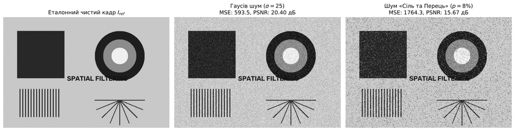

```python
def add_gaussian_noise(image, sigma, seed=42):
    """Адитивний гаусів шум N(0, sigma^2) з округленням і відсіканням до [0, 255]."""
    noise = np.random.default_rng(seed).normal(0.0, sigma, image.shape)
    return np.clip(np.rint(image.astype(np.float64) + noise), 0, 255).astype(np.uint8), noise

def add_salt_and_pepper_noise(image, prop, seed=43):
    """Імпульсний шум 'сіль та перець' точної щільності prop: різні піксельні позиції, половина 255, половина 0."""
    rng = np.random.default_rng(seed)
    n_noise = int(round(prop * image.size))
    idx = rng.choice(image.size, size=n_noise, replace=False)
    noisy = image.copy().ravel()
    noisy[idx[: n_noise // 2]] = 255
    noisy[idx[n_noise // 2:]] = 0
    return noisy.reshape(image.shape)

def calculate_metrics(ref, proc):
    """MSE та PSNR (дБ) для 8-бітних зображень."""
    mse = float(np.mean((ref.astype(np.float64) - proc.astype(np.float64)) ** 2))
    return mse, (float('inf') if mse == 0 else 10.0 * np.log10(255.0 ** 2 / mse))

def expected_mse_gauss(image, sigma, step=0.05):
    """Очікувана MSE гаусового шуму з відсіканням до [0, 255] (чисельне інтегрування по гістограмі)."""
    n = np.arange(-6 * sigma, 6 * sigma + 1e-9, step)
    pdf = np.exp(-n ** 2 / (2 * sigma ** 2)) / (sigma * np.sqrt(2 * np.pi))
    vals, cnts = np.unique(image, return_counts=True)
    return float(sum(c * np.sum(pdf * (np.clip(u + n, 0, 255) - u) ** 2) * step for u, c in zip(vals, cnts)) / image.size)

img_gauss_noisy, noise_g = add_gaussian_noise(img_clean, SIGMA_G)
img_sp_noisy = add_salt_and_pepper_noise(img_clean, P_SP)

mse_g0, psnr_g0 = calculate_metrics(img_clean, img_gauss_noisy)
mse_sp0, psnr_sp0 = calculate_metrics(img_clean, img_sp_noisy)

clipped_share = 100 * float(np.mean((img_clean + noise_g < -0.5) | (img_clean + noise_g > 255.5)))
changed_sp = 100 * float(np.mean(img_sp_noisy != img_clean))
mse_g_exp = expected_mse_gauss(img_clean, SIGMA_G)
mse_sp_exp = P_SP / 2 * float(np.mean((255.0 - img_clean) ** 2)) + P_SP / 2 * float(np.mean(img_clean.astype(float) ** 2))
dark_mask = img_clean < 60
mse_dark = float(np.mean((img_gauss_noisy[dark_mask].astype(float) - img_clean[dark_mask]) ** 2))
mse_bg = float(np.mean((img_gauss_noisy[img_clean == 200].astype(float) - 200) ** 2))

print("=" * 88)
print("ВЕРИФІКАЦІЯ МОДЕЛЕЙ ШУМУ")
print("=" * 88)
print(f"Гаусів шум:   задана σ² = {SIGMA_G ** 2:.1f}; виміряна MSE = {mse_g0:.1f}; очікувана з урахуванням відсікання = {mse_g_exp:.1f}; "
      f"відсічено {clipped_share:.1f} % пікселів")
print(f"              MSE на темних об'єктах (I < 60) = {mse_dark:.1f}; на світлому тлі (I = 200) = {mse_bg:.1f}")
print(f"Сіль та перець: ураження {changed_sp:.2f} % пікселів (задано {100 * P_SP:.1f} %); виміряна MSE = {mse_sp0:.1f}; теоретична = {mse_sp_exp:.1f}")
print(f"Без обробки: Гаус MSE = {mse_g0:.2f}, PSNR = {psnr_g0:.2f} дБ; S&P MSE = {mse_sp0:.2f}, PSNR = {psnr_sp0:.2f} дБ")
print("=" * 88)
assert abs(changed_sp - 100 * P_SP) < 0.01 and abs(mse_g0 / mse_g_exp - 1) < 0.05 and abs(mse_sp0 / mse_sp_exp - 1) < 0.05

fig, axes = plt.subplots(1, 3, figsize=(16, 5.2))
axes[0].imshow(img_clean, cmap='gray', vmin=0, vmax=255); axes[0].set_title("Еталонний чистий кадр $I_{ref}$")
axes[1].imshow(img_gauss_noisy, cmap='gray', vmin=0, vmax=255); axes[1].set_title(f"Гаусів шум ($\\sigma={SIGMA_G:.0f}$)\nMSE: {mse_g0:.1f}, PSNR: {psnr_g0:.2f} дБ")
axes[2].imshow(img_sp_noisy, cmap='gray', vmin=0, vmax=255); axes[2].set_title(f"Шум «Сіль та Перець» ($p={100 * P_SP:.0f}\\%$)\nMSE: {mse_sp0:.1f}, PSNR: {psnr_sp0:.2f} дБ")
for ax in axes:
    ax.axis('off')
plt.tight_layout()
plt.savefig("figures/noise_models_comparison.png", dpi=200)
plt.show()
```

## 4. Лінійне та нелінійне шумозаглушення (Box, Gauss, Median, Bilateral)

Фільтри застосовуються функціями OpenCV. Для перевірки кожен із них звіряється з незалежною реалізацією: двовимірна кореляція через `sliding_window_view` (межі відбиваються без повторення краю, що відповідає `BORDER_REFLECT_101`), `scipy.ndimage` та прямий розрахунок білатерального ядра за формулою. Розбіжності пояснюються округленням до 8 біт.

```
Верифікація фільтрів (|незалежна реалізація − OpenCV|, рівнів яскравості):
  Box: кореляція             max = 0.480; середнє = 0.2493
  Box: ndimage               max = 0.480; середнє = 0.2493
  Gauss: кореляція           max = 1.040; середнє = 0.2588
  Gauss: ndimage             max = 1.040; середнє = 0.2588
  Median: ndimage            max = 0.000; середнє = 0.0000
  Bilateral: пряма формула   max = 0.500; середнє = 0.2503
  Просторова вага bilateral на краю вікна: exp(−r²/2σ_s²) = 0.9988; число пікселів у круглому вікні: 49 з 81

================================================================================================
ПОРІВНЯЛЬНИЙ АНАЛІЗ ЯКОСТІ ПРОСТОРОВОЇ ФІЛЬТРАЦІЇ ШУМІВ
================================================================================================
Фільтр                             |  Гаус: MSE |   Гаус: PSNR |   S&P: MSE |    S&P: PSNR
------------------------------------------------------------------------------------------------
Без обробки (Raw)                  |     593.54 |     20.40 дБ |    1764.31 |     15.67 дБ
Box (5x5)                          |     369.01 |     22.46 дБ |     465.07 |     21.46 дБ
Gauss (5x5, s=1.5)                 |     271.49 |     23.79 дБ |     380.42 |     22.33 дБ
Median (5x5)                       |     126.17 |     27.12 дБ |     102.11 |     28.04 дБ
Bilateral (d=9, 80/80)             |      67.40 |     29.84 дБ |     690.38 |     19.74 дБ
================================================================================================
```

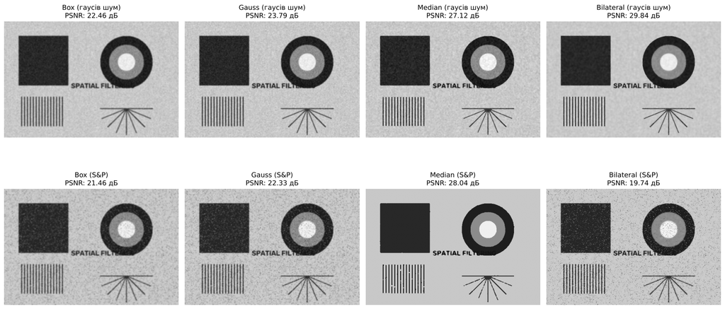

```python
def correlate_manual(img, kernel):
    """Пряма двовимірна кореляція g(x,y) = sum f(x+s, y+t) h(s,t) з відбиттям меж (REFLECT_101)."""
    a = kernel.shape[0] // 2
    win = sliding_window_view(np.pad(img.astype(np.float64), a, mode='reflect'), kernel.shape)
    return np.einsum('xyst,st->xy', win, kernel)

def gaussian_kernel_manual(size, sigma):
    ax = np.arange(size) - size // 2
    h = np.exp(-(ax[:, None] ** 2 + ax[None, :] ** 2) / (2.0 * sigma ** 2))
    return h / h.sum()

def bilateral_manual(img, d, sigma_c, sigma_s, chunk=40):
    """Пряма реалізація білатерального фільтра: кругле вікно радіуса d//2, просторова та фотометрична ваги."""
    r = d // 2
    f = img.astype(np.float32)
    ax = np.arange(-r, r + 1)
    dist2 = ax[:, None] ** 2 + ax[None, :] ** 2
    S = (np.exp(-dist2 / (2.0 * sigma_s ** 2)) * (dist2 <= r * r)).astype(np.float32)
    win_all = sliding_window_view(np.pad(f, r, mode='reflect'), (d, d))
    out = np.empty_like(f)
    for r0 in range(0, f.shape[0], chunk):
        w = win_all[r0:r0 + chunk]
        wt = S[None, None] * np.exp(-((w - f[r0:r0 + chunk, :, None, None]) ** 2) / (2.0 * sigma_c ** 2))
        out[r0:r0 + chunk] = (wt * w).sum((2, 3)) / wt.sum((2, 3))
    return out

def apply_filters(img):
    return {
        'Box':       cv2.blur(img, (K_BOX, K_BOX)),
        'Gauss':     cv2.GaussianBlur(img, (K_GAUSS, K_GAUSS), sigmaX=SIGMA_GAUSS),
        'Median':    cv2.medianBlur(img, K_MED),
        'Bilateral': cv2.bilateralFilter(img, d=BIL_D, sigmaColor=BIL_SIGMA_C, sigmaSpace=BIL_SIGMA_S),
    }

res_g, res_sp = apply_filters(img_gauss_noisy), apply_filters(img_sp_noisy)

# --- Верифікація реалізацій на зашумленому кадрі
chk = {}
chk['Box: кореляція'] = np.abs(correlate_manual(img_gauss_noisy, np.full((K_BOX, K_BOX), 1.0 / K_BOX ** 2)) - res_g['Box'])
chk['Box: ndimage'] = np.abs(ndimage.uniform_filter(img_gauss_noisy.astype(np.float64), size=K_BOX, mode='mirror') - res_g['Box'])
kg = gaussian_kernel_manual(K_GAUSS, SIGMA_GAUSS)
chk['Gauss: кореляція'] = np.abs(correlate_manual(img_gauss_noisy, kg) - res_g['Gauss'])
chk['Gauss: ndimage'] = np.abs(ndimage.gaussian_filter(img_gauss_noisy.astype(np.float64), SIGMA_GAUSS, truncate=(K_GAUSS // 2 - 0.4) / SIGMA_GAUSS, mode='mirror') - res_g['Gauss'])
chk['Median: ndimage'] = np.abs(ndimage.median_filter(img_gauss_noisy, size=K_MED, mode='nearest').astype(float) - res_g['Median'])   # medianBlur: BORDER_REPLICATE
bil_manual = bilateral_manual(img_gauss_noisy, BIL_D, BIL_SIGMA_C, BIL_SIGMA_S)
chk['Bilateral: пряма формула'] = np.abs(bil_manual - res_g['Bilateral'])
print("Верифікація фільтрів (|незалежна реалізація − OpenCV|, рівнів яскравості):")
for k_, v_ in chk.items():
    print(f"  {k_:<26} max = {v_.max():.3f}; середнє = {v_.mean():.4f}")
assert chk['Median: ndimage'].max() == 0 and all(chk[k_].max() <= 1.5 for k_ in chk)       # лінійні фільтри OpenCV використовують цілочисельне ядро та округлення
print(f"  Просторова вага bilateral на краю вікна: exp(−r²/2σ_s²) = {np.exp(-16 / (2 * BIL_SIGMA_S ** 2)):.4f}; число пікселів у круглому вікні: {int((np.add.outer(np.arange(-4, 5) ** 2, np.arange(-4, 5) ** 2) <= 16).sum())} з {BIL_D ** 2}")

# --- Зведена таблиця MSE / PSNR
names = {'Box': f'Box ({K_BOX}x{K_BOX})', 'Gauss': f'Gauss ({K_GAUSS}x{K_GAUSS}, s={SIGMA_GAUSS})', 'Median': f'Median ({K_MED}x{K_MED})',
         'Bilateral': f'Bilateral (d={BIL_D}, {BIL_SIGMA_C}/{BIL_SIGMA_S})'}
table = [dict(filter='Без обробки (Raw)', mse_gauss=mse_g0, psnr_gauss=psnr_g0, mse_sp=mse_sp0, psnr_sp=psnr_sp0)]
for k_ in names:
    mg, pg = calculate_metrics(img_clean, res_g[k_]); ms, ps = calculate_metrics(img_clean, res_sp[k_])
    table.append(dict(filter=names[k_], mse_gauss=mg, psnr_gauss=pg, mse_sp=ms, psnr_sp=ps))
print("\n" + "=" * 96)
print("ПОРІВНЯЛЬНИЙ АНАЛІЗ ЯКОСТІ ПРОСТОРОВОЇ ФІЛЬТРАЦІЇ ШУМІВ")
print("=" * 96)
print(f"{'Фільтр':<34} | {'Гаус: MSE':>10} | {'Гаус: PSNR':>12} | {'S&P: MSE':>10} | {'S&P: PSNR':>12}")
print("-" * 96)
for r_ in table:
    print(f"{r_['filter']:<34} | {r_['mse_gauss']:10.2f} | {r_['psnr_gauss']:9.2f} дБ | {r_['mse_sp']:10.2f} | {r_['psnr_sp']:9.2f} дБ")
print("=" * 96)

fig, axes = plt.subplots(2, 4, figsize=(18, 9.2))
for j, k_ in enumerate(names):
    axes[0, j].imshow(res_g[k_], cmap='gray', vmin=0, vmax=255)
    axes[0, j].set_title(f"{k_} (гаусів шум)\nPSNR: {calculate_metrics(img_clean, res_g[k_])[1]:.2f} дБ")
    axes[1, j].imshow(res_sp[k_], cmap='gray', vmin=0, vmax=255)
    axes[1, j].set_title(f"{k_} (S&P)\nPSNR: {calculate_metrics(img_clean, res_sp[k_])[1]:.2f} дБ")
for ax in axes.flat:
    ax.axis('off')
plt.tight_layout()
plt.savefig("figures/smoothing_filters_results.png", dpi=200)
plt.show()
```

## 5. Розподіл похибки: однорідні ділянки та зона контурів, чутливість до параметрів

Загальна $\mathrm{MSE}$ не показує, **де** фільтр помиляється. Тому похибка розкладається за зонами, визначеними за еталонним кадром: **зона контурів** — піксели в околі $\pm2$ px від точок із градієнтом Собеля $|\nabla I|>40$; **однорідна зона** — піксели, віддалені від контурів більш ніж на $4$ px. Також досліджується, як якість залежить від параметрів: розмір вікна $K$ (Box, Median), $\sigma$ Гаусса (розмір ядра $2\lceil3\sigma\rceil+1$) та $\sigma_c$ білатерального фільтра.

```
Зона контурів: 16.2 % кадру; однорідна зона: 77.6 % кадру

============================================================================================
Гаусів шум                            MSE загальна   MSE однорідна   MSE контури контури/однорідна
Без обробки (Raw)                            593.5           598.8         573.2               1.0
Box (5x5)                                    369.0            24.9        2156.3              86.6
Gauss (5x5, s=1.5)                           271.5            30.7        1522.6              49.7
Median (5x5)                                 126.2            39.4         577.4              14.7
Bilateral (d=9, 80/80)                        67.4            17.9         324.6              18.2
============================================================================================
Теорія для лінійних фільтрів в однорідній зоні: MSE_raw·Σh² -> Box: 24.0 (виміряно 24.9); Gauss: 29.9 (виміряно 30.7); Σh²: Box = 0.0400, Gauss = 0.0500

PSNR, дБ, залежно від розміру вікна K:        K=3  K=5  K=7  K=9  K=11
  Box,    гаусів шум    24.30  22.46  20.51  19.59  18.95
  Median, гаусів шум    26.84  27.12  19.88  19.15  18.85
  Box,    S&P           21.98  21.46  20.03  19.25  18.69
  Median, S&P           30.56  28.04  18.80  18.44  18.35

PSNR, дБ, залежно від σ Гаусса:  σ=0.5  σ=0.8  σ=1.0  σ=1.5  σ=2.0  σ=2.5  σ=3.0
  Gauss, гаусів шум      23.80   25.44   24.89   23.13   21.77   20.74   20.07
  Gauss, S&P             19.16   22.37   22.66   21.99   21.06   20.24   19.67

PSNR, дБ, залежно від σ_c білатерального (d = 9, σ_s = 80):  σc=10  σc=20  σc=40  σc=60  σc=80  σc=120  σc=200
  Bilateral, гаусів шум    21.41   24.13   29.66   31.55   29.84   25.65   22.66
  Bilateral, S&P           15.68   15.86   16.10   16.65   19.74   23.64   22.20
```

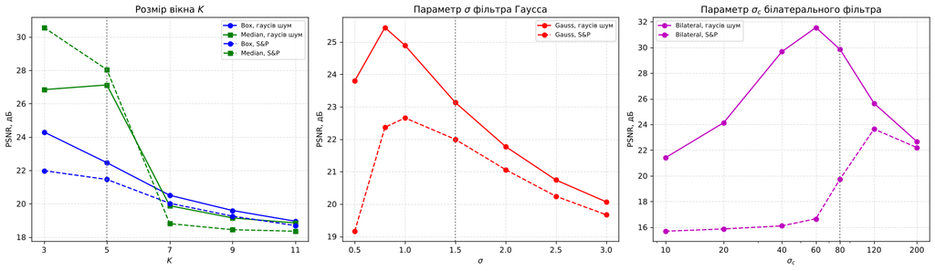

```python
gx = cv2.Sobel(img_clean, cv2.CV_32F, 1, 0, ksize=3); gy = cv2.Sobel(img_clean, cv2.CV_32F, 0, 1, ksize=3)
grad_clean = np.hypot(gx, gy)
edge_core = (grad_clean > 40).astype(np.uint8)
edge_zone = cv2.dilate(edge_core, np.ones((5, 5), np.uint8)) > 0
flat_zone = ~(cv2.dilate(edge_core, np.ones((9, 9), np.uint8)) > 0)

def zone_mse(ref, proc, zone):
    return float(np.mean((ref.astype(np.float64)[zone] - proc.astype(np.float64)[zone]) ** 2))

print(f"Зона контурів: {100 * edge_zone.mean():.1f} % кадру; однорідна зона: {100 * flat_zone.mean():.1f} % кадру")
print("\n" + "=" * 92)
print(f"{'Гаусів шум':<36}{'MSE загальна':>14}{'MSE однорідна':>16}{'MSE контури':>14}{'контури/однорідна':>18}")
zone_table = []
for nm, im in [("Без обробки (Raw)", img_gauss_noisy)] + [(names[k_], res_g[k_]) for k_ in names]:
    a, f_, e_ = zone_mse(img_clean, im, np.ones_like(edge_zone)), zone_mse(img_clean, im, flat_zone), zone_mse(img_clean, im, edge_zone)
    zone_table.append(dict(filter=nm, mse_total=a, mse_flat=f_, mse_edge=e_))
    print(f"{nm:<36}{a:14.1f}{f_:16.1f}{e_:14.1f}{e_ / f_:18.1f}")
print("=" * 92)
mse_flat_raw = zone_table[0]['mse_flat']
sum_h2 = {'Box': 1.0 / K_BOX ** 2, 'Gauss': float((gaussian_kernel_manual(K_GAUSS, SIGMA_GAUSS) ** 2).sum())}
print(f"Теорія для лінійних фільтрів в однорідній зоні: MSE_raw·Σh² -> Box: {mse_flat_raw * sum_h2['Box']:.1f} (виміряно {zone_table[1]['mse_flat']:.1f}); "
      f"Gauss: {mse_flat_raw * sum_h2['Gauss']:.1f} (виміряно {zone_table[2]['mse_flat']:.1f}); Σh²: Box = {sum_h2['Box']:.4f}, Gauss = {sum_h2['Gauss']:.4f}")

# --- Чутливість до параметрів
ps = lambda ref_proc: calculate_metrics(img_clean, ref_proc)[1]
K_list = [3, 5, 7, 9, 11]
sig_list = [0.5, 0.8, 1.0, 1.5, 2.0, 2.5, 3.0]
sc_list = [10, 20, 40, 60, 80, 120, 200]
sw = dict(K=K_list, sigma=sig_list, sigma_c=sc_list)
sw['box_g'] = [ps(cv2.blur(img_gauss_noisy, (k, k))) for k in K_list];  sw['box_sp'] = [ps(cv2.blur(img_sp_noisy, (k, k))) for k in K_list]
sw['med_g'] = [ps(cv2.medianBlur(img_gauss_noisy, k)) for k in K_list]; sw['med_sp'] = [ps(cv2.medianBlur(img_sp_noisy, k)) for k in K_list]
ksz = lambda s: 2 * int(np.ceil(3 * s)) + 1
sw['gauss_g'] = [ps(cv2.GaussianBlur(img_gauss_noisy, (ksz(s), ksz(s)), s)) for s in sig_list]
sw['gauss_sp'] = [ps(cv2.GaussianBlur(img_sp_noisy, (ksz(s), ksz(s)), s)) for s in sig_list]
sw['bil_g'] = [ps(cv2.bilateralFilter(img_gauss_noisy, BIL_D, c, BIL_SIGMA_S)) for c in sc_list]
sw['bil_sp'] = [ps(cv2.bilateralFilter(img_sp_noisy, BIL_D, c, BIL_SIGMA_S)) for c in sc_list]

print(f"\nPSNR, дБ, залежно від розміру вікна K:        " + "  ".join(f"K={k}" for k in K_list))
for lab, key in [("Box,    гаусів шум", 'box_g'), ("Median, гаусів шум", 'med_g'), ("Box,    S&P", 'box_sp'), ("Median, S&P", 'med_sp')]:
    print(f"  {lab:<20}" + "".join(f"{v:7.2f}" for v in sw[key]))
print(f"\nPSNR, дБ, залежно від σ Гаусса:  " + "  ".join(f"σ={s}" for s in sig_list))
for lab, key in [("Gauss, гаусів шум", 'gauss_g'), ("Gauss, S&P", 'gauss_sp')]:
    print(f"  {lab:<20}" + "".join(f"{v:8.2f}" for v in sw[key]))
print(f"\nPSNR, дБ, залежно від σ_c білатерального (d = 9, σ_s = 80):  " + "  ".join(f"σc={c}" for c in sc_list))
for lab, key in [("Bilateral, гаусів шум", 'bil_g'), ("Bilateral, S&P", 'bil_sp')]:
    print(f"  {lab:<22}" + "".join(f"{v:8.2f}" for v in sw[key]))

fig, axes = plt.subplots(1, 3, figsize=(17, 5))
ax = axes[0]
ax.plot(K_list, sw['box_g'], 'bo-', label='Box, гаусів шум'); ax.plot(K_list, sw['med_g'], 'gs-', label='Median, гаусів шум')
ax.plot(K_list, sw['box_sp'], 'bo--', label='Box, S&P'); ax.plot(K_list, sw['med_sp'], 'gs--', label='Median, S&P')
ax.axvline(K_BOX, color='gray', ls=':'); ax.set_title("Розмір вікна $K$"); ax.set_xlabel("$K$"); ax.set_ylabel("PSNR, дБ"); ax.set_xticks(K_list); ax.grid(True); ax.legend(fontsize=8)
ax = axes[1]
ax.plot(sig_list, sw['gauss_g'], 'ro-', label='Gauss, гаусів шум'); ax.plot(sig_list, sw['gauss_sp'], 'ro--', label='Gauss, S&P')
ax.axvline(SIGMA_GAUSS, color='gray', ls=':'); ax.set_title("Параметр $\\sigma$ фільтра Гаусса"); ax.set_xlabel("$\\sigma$"); ax.set_ylabel("PSNR, дБ"); ax.grid(True); ax.legend(fontsize=8)
ax = axes[2]
ax.plot(sc_list, sw['bil_g'], 'mo-', label='Bilateral, гаусів шум'); ax.plot(sc_list, sw['bil_sp'], 'mo--', label='Bilateral, S&P')
ax.axvline(BIL_SIGMA_C, color='gray', ls=':'); ax.set_xscale('log'); ax.set_xticks(sc_list); ax.set_xticklabels([str(c) for c in sc_list])
ax.set_title("Параметр $\\sigma_c$ білатерального фільтра"); ax.set_xlabel("$\\sigma_c$"); ax.set_ylabel("PSNR, дБ"); ax.grid(True); ax.legend(fontsize=8)
plt.tight_layout()
plt.savefig("figures/filter_parameter_sweep.png", dpi=200)
plt.show()
```

## 6. Підвищення різкості контурів дискретним оператором Лапласа

Відгук Лапласа обчислюється у форматі `float32` (щоб не втратити від'ємні значення), далі $I_{sharp}=\mathrm{clip}(I+k\,I_{lap},0,255)$. Для оцінки використовуються: середня величина градієнта Собеля у зоні контурів ($G_{edge}$) та в однорідній зоні ($G_{flat}$, фактично міра шуму), їх відношення, частка відсічених пікселів (перевищення діапазону, ореоли) та $\mathrm{PSNR}$ відносно еталона. Ядро звіряється з `scipy.ndimage.laplace` (4-зв'язне, центр $-4$): відгук такого оператора має протилежний знак щодо ядра з центром $+4$. Також досліджується залежність від $k$ та підсилення шуму ядром: сума квадратів коефіцієнтів $\sum h^2=8^2+8=72$, тобто СКВ шуму на виході Лапласіана дорівнює $\sigma\sqrt{72}\approx8.5\sigma$.

```
Ядро Лапласа: сума коефіцієнтів = 0 (однорідні ділянки не змінюються); Σh² = 72, очікуване СКВ шуму на виході σ·√72 = 212.1 при σ = 25

========================================================================================================
Зображення                                   G_edge   G_flat  G_edge/G_flat       MSE   PSNR, дБ
Еталон                                        242.1      0.0              —       0.0          ∞
Еталон + Лапласіан                            367.5      0.0              —     175.0      25.70
Гаусів шум                                    301.9    106.3            2.8     593.5      20.40
Гаусів шум + Лапласіан (без фільтрації)       480.3    352.3            1.4    8698.3       8.74
Bilateral                                     214.7     14.4           15.0      67.4      29.84
Bilateral + Лапласіан                         371.5     60.9            6.1     490.5      21.22
========================================================================================================
Відсічено пікселів (вихід за [0, 255]) при k = 0.6: еталон 6.54 %; після Bilateral 6.24 %; зашумлений кадр 48.50 %
Виміряне СКВ відгуку Лапласіана на однорідному фоні зашумленого кадру: 207.5

     k   PSNR еталон+Лапл.   PSNR Bilateral+Лапл.   G_edge/G_flat (Bilateral+Лапл.)
  0.00                 inf                  29.84                              15.0
  0.10               28.45                  28.23                              13.0
  0.20               27.11                  25.58                              11.1
  0.30               26.41                  24.16                               9.2
  0.40               25.98                  23.05                               7.9
  0.50               25.80                  22.08                               6.9
  0.60               25.70                  21.22                               6.1
  0.80               25.55                  19.76                               5.0
  1.00               25.43                  18.57                               4.3
  1.25               25.34                  17.37                               3.7
  1.50               25.28                  16.38                               3.3
Максимум PSNR після Bilateral + Лапласіан — при k = 0.0 (29.84 дБ); варіант: k = 0.6
```

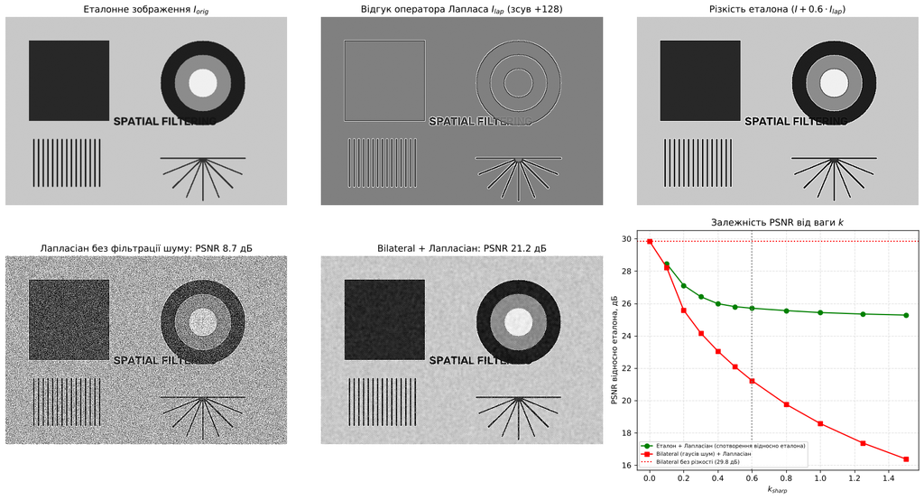

```python
kernel_lap8 = np.array([[-1.0, -1.0, -1.0], [-1.0, 8.0, -1.0], [-1.0, -1.0, -1.0]], dtype=np.float32)

def sharpen(img, k, kernel=kernel_lap8):
    """I_sharp = I + k * Laplace(I); повертає результат до відсікання, після та відгук Лапласа."""
    lap = cv2.filter2D(img.astype(np.float32), cv2.CV_32F, kernel)
    raw = img.astype(np.float32) + k * lap
    return raw, np.clip(raw, 0, 255).astype(np.uint8), lap

# Верифікація ядра: 4-зв'язне ядро з центром +4 дає відгук, протилежний ndimage.laplace (центр -4); ядро 8-зв'язне звіряється з кореляцією
kernel_lap4 = np.array([[0, -1, 0], [-1, 4, -1], [0, -1, 0]], dtype=np.float32)
lap4_cv = cv2.filter2D(img_clean.astype(np.float32), cv2.CV_32F, kernel_lap4)
lap4_nd = ndimage.laplace(img_clean.astype(np.float64), mode='mirror')
assert np.allclose(lap4_cv, -lap4_nd, atol=1e-3)
lap8_cv = cv2.filter2D(img_clean.astype(np.float32), cv2.CV_32F, kernel_lap8)
assert np.allclose(lap8_cv, correlate_manual(img_clean, kernel_lap8), atol=1e-3)
print(f"Ядро Лапласа: сума коефіцієнтів = {kernel_lap8.sum():.0f} (однорідні ділянки не змінюються); Σh² = {(kernel_lap8 ** 2).sum():.0f}, "
      f"очікуване СКВ шуму на виході σ·√72 = {SIGMA_G * np.sqrt(72):.1f} при σ = {SIGMA_G:.0f}")

raw_clean, sharp_clean, lap_clean = sharpen(img_clean, K_SHARP)
filt_bil = res_g['Bilateral']
raw_bil, sharp_bil, _ = sharpen(filt_bil, K_SHARP)
raw_noisy, sharp_noisy, _ = sharpen(img_gauss_noisy, K_SHARP)

def edge_flat_gradients(im):
    f32 = im.astype(np.float32)
    g = np.hypot(cv2.Sobel(f32, cv2.CV_32F, 1, 0, ksize=3), cv2.Sobel(f32, cv2.CV_32F, 0, 1, ksize=3))
    return float(g[edge_zone].mean()), float(g[flat_zone].mean())

rows = []
for nm, im in [("Еталон", img_clean), ("Еталон + Лапласіан", sharp_clean), ("Гаусів шум", img_gauss_noisy), ("Гаусів шум + Лапласіан (без фільтрації)", sharp_noisy),
               ("Bilateral", filt_bil), ("Bilateral + Лапласіан", sharp_bil)]:
    ge, gf = edge_flat_gradients(im)
    mse_, psnr_ = calculate_metrics(img_clean, im)
    rows.append(dict(image=nm, g_edge=ge, g_flat=gf, ratio=ge / max(gf, 1e-9), mse=mse_, psnr=psnr_))
clip_pct = lambda raw: 100 * float(np.mean((raw < 0) | (raw > 255)))
print("\n" + "=" * 104)
print(f"{'Зображення':<42}{'G_edge':>9}{'G_flat':>9}{'G_edge/G_flat':>15}{'MSE':>10}{'PSNR, дБ':>11}")
for r_ in rows:
    ratio_txt = "—" if r_['g_flat'] < 0.5 else f"{r_['ratio']:.1f}"
    psnr_txt = "∞" if r_['mse'] == 0 else f"{r_['psnr']:.2f}"
    print(f"{r_['image']:<42}{r_['g_edge']:9.1f}{r_['g_flat']:9.1f}{ratio_txt:>15}{r_['mse']:10.1f}{psnr_txt:>11}")
print("=" * 104)
print(f"Відсічено пікселів (вихід за [0, 255]) при k = {K_SHARP}: еталон {clip_pct(raw_clean):.2f} %; після Bilateral {clip_pct(raw_bil):.2f} %; "
      f"зашумлений кадр {clip_pct(raw_noisy):.2f} %")
print(f"Виміряне СКВ відгуку Лапласіана на однорідному фоні зашумленого кадру: {np.std(cv2.filter2D(img_gauss_noisy.astype(np.float32), cv2.CV_32F, kernel_lap8)[flat_zone]):.1f}")

# --- Залежність від k
k_list = [0.0, 0.1, 0.2, 0.3, 0.4, 0.5, 0.6, 0.8, 1.0, 1.25, 1.5]
psnr_k_clean = [calculate_metrics(img_clean, sharpen(img_clean, k)[1])[1] if k > 0 else float('inf') for k in k_list]
psnr_k_bil = [calculate_metrics(img_clean, sharpen(filt_bil, k)[1])[1] for k in k_list]
ratio_k_bil = [edge_flat_gradients(sharpen(filt_bil, k)[1]) for k in k_list]
k_best = k_list[int(np.argmax(psnr_k_bil))]
print(f"\n{'k':>6}{'PSNR еталон+Лапл.':>20}{'PSNR Bilateral+Лапл.':>23}{'G_edge/G_flat (Bilateral+Лапл.)':>34}")
for k, pc, pb, (ge, gf) in zip(k_list, psnr_k_clean, psnr_k_bil, ratio_k_bil):
    print(f"{k:6.2f}{pc:20.2f}{pb:23.2f}{ge / gf:34.1f}")
print(f"Максимум PSNR після Bilateral + Лапласіан — при k = {k_best} ({max(psnr_k_bil):.2f} дБ); варіант: k = {K_SHARP}")

fig, axes = plt.subplots(2, 3, figsize=(17, 9.5))
axes[0, 0].imshow(img_clean, cmap='gray', vmin=0, vmax=255); axes[0, 0].set_title("Еталонне зображення $I_{orig}$")
axes[0, 1].imshow(np.clip(lap_clean + 128, 0, 255).astype(np.uint8), cmap='gray', vmin=0, vmax=255); axes[0, 1].set_title("Відгук оператора Лапласа $I_{lap}$ (зсув +128)")
axes[0, 2].imshow(sharp_clean, cmap='gray', vmin=0, vmax=255); axes[0, 2].set_title(f"Різкість еталона ($I+{K_SHARP}\\cdot I_{{lap}}$)")
axes[1, 0].imshow(sharp_noisy, cmap='gray', vmin=0, vmax=255); axes[1, 0].set_title(f"Лапласіан без фільтрації шуму: PSNR {rows[3]['psnr']:.1f} дБ")
axes[1, 1].imshow(sharp_bil, cmap='gray', vmin=0, vmax=255); axes[1, 1].set_title(f"Bilateral + Лапласіан: PSNR {rows[5]['psnr']:.1f} дБ")
for ax in list(axes[0]) + list(axes[1, :2]):
    ax.axis('off')
ax = axes[1, 2]
ax.plot(k_list[1:], psnr_k_clean[1:], 'go-', label='Еталон + Лапласіан (спотворення відносно еталона)')
ax.plot(k_list, psnr_k_bil, 'rs-', label='Bilateral (гаусів шум) + Лапласіан')
ax.axhline(rows[4]['psnr'], color='r', ls=':', label=f"Bilateral без різкості ({rows[4]['psnr']:.1f} дБ)")
ax.axvline(K_SHARP, color='gray', ls=':'); ax.set_title("Залежність PSNR від ваги $k$"); ax.set_xlabel("$k_{sharp}$"); ax.set_ylabel("PSNR відносно еталона, дБ")
ax.grid(True); ax.legend(fontsize=7)
plt.tight_layout()
plt.savefig("figures/sharpening_laplacian.png", dpi=200)
plt.show()
```

## 7. Експорт результатів

```python
with open("data/metrics_table.csv", "w", newline="", encoding="utf-8") as f:
    w = csv.DictWriter(f, fieldnames=list(table[0].keys())); w.writeheader(); w.writerows(table)
with open("data/zone_mse_gauss.csv", "w", newline="", encoding="utf-8") as f:
    w = csv.DictWriter(f, fieldnames=list(zone_table[0].keys())); w.writeheader(); w.writerows(zone_table)
cv2.imwrite("data/noisy_gaussian.png", img_gauss_noisy); cv2.imwrite("data/noisy_salt_pepper.png", img_sp_noisy)
for k_ in names:
    cv2.imwrite(f"data/filtered_gauss_{k_.lower()}.png", res_g[k_]); cv2.imwrite(f"data/filtered_sp_{k_.lower()}.png", res_sp[k_])
cv2.imwrite("data/sharpened_reference.png", sharp_clean); cv2.imwrite("data/sharpened_bilateral.png", sharp_bil)

results = dict(
    variant=2,
    params=dict(sigma_g=SIGMA_G, p_sp=P_SP, K_box=K_BOX, K_gauss=K_GAUSS, K_med=K_MED, sigma_gauss=SIGMA_GAUSS,
                bilateral=dict(d=BIL_D, sigma_c=BIL_SIGMA_C, sigma_s=BIL_SIGMA_S), k_sharp=K_SHARP),
    noise_model=dict(mse_gauss_measured=mse_g0, mse_gauss_expected_clipped=mse_g_exp, mse_gauss_nominal=SIGMA_G ** 2, clipped_share_pct=clipped_share,
                     mse_dark_objects=mse_dark, mse_light_background=mse_bg, sp_changed_pct=changed_sp, mse_sp_measured=mse_sp0, mse_sp_expected=mse_sp_exp),
    verification_max_diff={k_: float(v_.max()) for k_, v_ in chk.items()},
    metrics=table, zone_mse=zone_table, zones=dict(edge_pct=100 * float(edge_zone.mean()), flat_pct=100 * float(flat_zone.mean())),
    parameter_sweep=sw, sharpening=dict(rows=rows, clipped_pct=dict(clean=clip_pct(raw_clean), bilateral=clip_pct(raw_bil), noisy=clip_pct(raw_noisy)),
                                        k_sweep=dict(k=k_list, psnr_clean=[float(x) for x in psnr_k_clean], psnr_bilateral=psnr_k_bil, k_best=k_best)),
)
def clean_inf(o):
    """JSON не підтримує Infinity: нескінченні PSNR (нульова похибка) записуються як null."""
    if isinstance(o, dict):  return {k: clean_inf(v) for k, v in o.items()}
    if isinstance(o, (list, tuple)): return [clean_inf(v) for v in o]
    if isinstance(o, (float, np.floating)) and not np.isfinite(o): return None
    return o
with open("data/results.json", "w", encoding="utf-8") as f:
    json.dump(clean_inf(results), f, ensure_ascii=False, indent=1, default=float)
print("Готово: figures/, data/")
```

```
Готово: figures/, data/
```

## Висновки

1. **Моделі шумів.** Реальна $\mathrm{MSE}$ гаусового шуму ($\sigma_g=25$) дорівнює $593.5$, а не номінальним $\sigma_g^2=625$: значення відсікаються до $[0,255]$ (відсічено $3.1$ % пікселів), і для темних об'єктів ($I<60$) $\mathrm{MSE}=543$, для світлого тла ($I=200$) — $610$. Чисельне інтегрування з урахуванням відсікання дає очікувані $592.3$, що збігається з виміряним. Для шуму «сіль та перець» уражено рівно $8.00$ % пікселів (вибірка без повторень), виміряна $\mathrm{MSE}=1764.3$ проти теоретичних $1768.7$. Початкові $\mathrm{PSNR}$: $20.40$ дБ (гаус) та $15.67$ дБ (S&P).
2. **Коректність фільтрів.** Кожен фільтр OpenCV збігається з незалежною реалізацією: Box та Gauss — з прямою кореляцією та `scipy.ndimage` (розбіжність не більше $0.48$ та $1.04$ рівня через цілочисельне ядро й округлення), медіана — з `ndimage.median_filter` повністю (різниця 0), білатеральний — з прямим розрахунком за формулою ($\le0.5$). Параметр $\sigma_s=80$ значно більший за радіус вікна ($d=9$), тому просторова вага на краю вікна дорівнює $0.9988$: фільтр практично зважує пікселі лише за яскравістю ($\sigma_c$), а вікно в OpenCV кругле (49 із 81 пікселів).
3. **Порівняння фільтрів за $\mathrm{MSE}/\mathrm{PSNR}$.** Гаусів шум: Box $22.46$ дБ, Gauss $23.79$ дБ, Median $27.12$ дБ, Bilateral $29.84$ дБ ($\mathrm{MSE}=369.0;\,271.5;\,126.2;\,67.4$). Шум S&P: Box $21.46$ дБ, Gauss $22.33$ дБ, Median $28.04$ дБ, Bilateral $19.74$ дБ. Лінійні фільтри при імпульсному шумі лише розмивають імпульси у плями, медіана видаляє їх як викиди ранжирування; білатеральний фільтр на S&P гірший навіть за Gauss, бо імпульс (різниця яскравості $\approx200$) значно більший за $\sigma_c=80$, і фільтр сприймає його як контур та залишає. Числа з прикладу в тексті лабораторної (напр. Median на S&P $35.5$ дБ, Box $27.6$ дБ) на цьому кадрі не відтворюються: розрахункові значення — $28.0$ та $21.5$ дБ.
4. **Розподіл похибки за зонами** (контури — $16.2$ % кадру, однорідна зона — $77.6$ %). В однорідній зоні лінійні фільтри зменшують $\mathrm{MSE}$ з $598.8$ до $24.9$ (Box) та $30.7$ (Gauss), що узгоджується з теорією $\mathrm{MSE}_{raw}\cdot\sum h^2=24.0$ та $29.9$ ($\sum h^2=1/25$ та $0.05$); білатеральний дає $17.9$, медіана $39.4$. На контурах картина інша: Box ($2156$) і Gauss ($1523$) **гірші за зашумлений кадр** ($573$) у $3.8$ та $2.7$ раза, медіана дає $577$, а білатеральний — $325$ (найменша похибка в обох зонах). Отже, виграш Box та Gauss у загальній $\mathrm{MSE}$ забезпечує лише переважна частка однорідного тла, ціною розмиття контурів.
5. **Чутливість до параметрів.** Параметри варіанта (компроміс загального призначення) не є оптимальними саме для цього кадру з тонкими 2-пікселними лініями: Gauss найкращий при $\sigma=0.8$ ($25.44$ дБ проти $23.13$ дБ при $\sigma=1.5$), Box краще при $K=3$ ($24.30$ дБ проти $22.46$ дБ), медіана при S&P краща при $K=3$ ($30.56$ проти $28.04$ дБ), а при $K\ge7$ різко деградує ($\approx19$ дБ), бо вікно перевищує подвійну ширину тонких ліній і текстових штрихів та видаляє їх. Для білатерального фільтра максимум при $\sigma_c=60$ ($31.55$ дБ проти $29.84$ дБ при $\sigma_c=80$): при $\sigma_c\ll\sigma_g$ ($10$ — $21.41$ дБ) шум сприймається як контур і не усувається, при $\sigma_c\gg\sigma_g$ ($200$ — $22.66$ дБ) фільтр вироджується в усереднення.
6. **Підвищення різкості Лапласіаном** ($k=0.6$). Сума коефіцієнтів ядра дорівнює нулю (однорідні ділянки не змінюються), а $\sum h^2=72$, тому СКВ шуму на виході зростає в $\sqrt{72}\approx8.5$ раза (виміряно $207.5$ при $\sigma=25$); застосування до зашумленого кадру без фільтрації дає $\mathrm{PSNR}=8.74$ дБ, відсічено $48.5$ % пікселів. На чистому еталоні середній градієнт на контурах зростає з $242.1$ до $367.5$ ($\times1.5$, відсічено $6.5$ % пікселів, ореоли), $\mathrm{PSNR}$ відносно еталона $25.70$ дБ. Після білатерального фільтра градієнт контурів $214.7\to371.5$ (більший за еталонний, тобто контури не відновлюються, а перепідсилюються), а градієнт на однорідній зоні (міра шуму) зростає з $14.4$ до $60.9$, відношення «контури / шум» падає з $15.0$ до $6.1$, $\mathrm{PSNR}$ — з $29.84$ до $21.22$ дБ. $\mathrm{PSNR}$ відносно еталона монотонно спадає із зростанням $k$ ($28.23$ дБ при $k=0.1$; $25.58$ дБ при $k=0.2$), тож підвищення різкості доцільне лише з малою вагою ($k\lesssim0.2$) і після ефективного шумозаглушення.

## Контрольні питання

### 1. У чому полягає математична та алгоритмічна різниця між операціями двовимірної просторової згортки та кореляції при обробці зображень?

- **Математична різниця:**
- **Кореляція** обчислює суму добутків коефіцієнтів ядра $w(s, t)$ та відповідних пікселів зображення $f(x + s, y + t)$ без зміни орієнтації ядра:

$$(w \star f)(x, y) = \sum_{s=-a}^{a} \sum_{t=-b}^{b} w(s, t) \, f(x + s, y + t)$$

- **Згортка** відрізняється інверсією знаків зміщення координат (віддзеркаленням ядра по обох осях):

$$(w * f)(x, y) = \sum_{s=-a}^{a} \sum_{t=-b}^{b} w(s, t) \, f(x - s, y - t)$$

- Згортка є **комутативною та асоціативною** (що дозволяє об'єднувати каскад фільтрів в одне ядро та переходити у частотну область за теоремою про згортку), тоді як кореляція цих властивостей не має.
- **Алгоритмічна різниця:**
- Під час **кореляції** маска фільтра накладається на окіл поточного пікселя $(x, y)$ у вихідному вигляді, після чого виконується поелементне множення з підсумовуванням.
- Під час **згортки** маску фільтра попередньо **повертають на $180^\circ$** (віддзеркалюють по горизонталі та вертикалі), і лише після цього переміщують по зображенню для обчислення суми добутків.
- *Примітка:* для симетричних ядер (наприклад, усереднюючого або Гаусового фільтра) результати згортки та кореляції повністю збігаються.

### 2. Яким чином вибір розміру ядра $K \times K$ усереднюючого та Гаусового фільтрів впливає на ступінь придушення шуму та чіткість дрібних деталей зображення?

Розмір ядра $K \times K$ задає площу локального околу усереднення та визначає компроміс між **рівнем придушення шуму** і **збереженням чіткості деталей**:

- **Збільшення розміру ядра ($K$ велике):**
- *Придушення шуму:* суттєво посилюється, оскільки випадкові флуктуації яскравості усереднюються за більшою кількістю пікселів (дисперсія некорельованого шуму зменшується приблизно пропорційно $1/K^2$ для усереднюючого фільтра).
- *Чіткість деталей:* значно знижується — виникає сильне розмиття, зникають дрібні текстури та тонкі лінії, розмиваються контрастні границі об'єктів. При цьому усереднюючий фільтр із великим $K$ може створювати «блокові» артефакти, тоді як Гаусовий фільтр розмиває зображення більш плавно завдяки спаданню ваг від центру до периферії.
- **Зменшення розміру ядра ($K$ мале, наприклад $3 \times 3$):**
- *Придушення шуму:* слабке, оскільки в розрахунку беруть участь лише найближчі сусідні пікселі.
- *Чіткість деталей:* висока — контури, дрібні елементи та текстури зберігаються майже без спотворень.

### 3. Чому лінійні фільтри низьких частот (Box, Gauss) є малоефективними для усунення імпульсного шуму типу «сіль та перець»?

Імпульсний шум типу «сіль та перець» складається з поодиноких пікселів з екстремальними значеннями інтенсивності ($0$ — чорний «перець» або $L-1$ — біла «сіль»), які різко відрізняються від фону. Лінійні фільтри (Box, Gauss) малоефективні проти нього з таких причин:

- **Відсутність відсікання викидів:** лінійний фільтр обчислює зважене середнє *всіх* пікселів у вікні $K \times K$, тому екстремальне значення $0$ або $L-1$ безпосередньо входить у суму та суттєво зміщує результат.
- **«Розмазування» шуму:** замість видалення імпульсної перешкоди фільтр розподіляє її енергію між сусідніми непошкодженими пікселями, перетворюючи поодинокий точковий дефект на розмиту темну або світлу пляму розміром $K \times K$.
- **Деградація різкості:** спроба зменшити вплив імпульсу шляхом збільшення розміру ядра $K$ призводить до надмірного розмиття корисних деталей і границь по всьому зображенню.

### 4. Опишіть принцип роботи нелінійного медіанного фільтра. Чому він належить до класу порядкових (рангових) статистичних фільтрів?

- **Принцип роботи медіанного фільтра:**
1. Навколо поточного пікселя $(x, y)$ формується ковзне вікно розміром $K \times K$ (зазвичай із непарним $K$, щоб кількість елементів $N = K^2$ була непарною).
2. Усі $N$ значень яскравості пікселів, що потрапили у вікно, зчитуються в масив і **сортуються за зростанням (або спаданням)**:

$$I_{(1)} \le I_{(2)} \le \dots \le I_{(N)}$$

3. Із відсортованого ряду обирається центральне значення — **медіана** $I_{((N+1)/2)}$, яким замінюється значення центрального пікселя вихідного зображення.
- **Чому він належить до класу порядкових (рангових) статистичних фільтрів:** Порядкові (рангові) фільтри ґрунтуються не на лінійному зважуванні інтенсивностей (множенні на коефіцієнти маски), а на **впорядкуванні (ранжуванні)** вибірки пікселів локального околу за величиною яскравості та виборі елемента з фіксованим порядковим номером (рангом) у варіаційному ряді (наприклад, мінімуму з рангом $1$, максимуму з рангом $N$ або медіани із середнім рангом $(N+1)/2$). Операція сортування є нелінійною, тому медіанний фільтр є нелінійним ранговим фільтром.

### 5. За рахунок якого механізму білатеральний фільтр здатний одночасно ефективно згладжувати флуктуаційний шум на однорідних ділянках та повністю зберігати високу різкість границь об'єктів?

Білатеральний фільтр використовує **подвійне нелінійне зважування** кожного сусіднього пікселя $q$ відносно центрального пікселя $p$, поєднуючи просторову близькість та подібність за яскравістю:

$$I_{\text{filtered}}(p) = \frac{1}{W_p} \sum_{q \in \Omega} I(q) \cdot G_{\sigma_s}(\Vert{}p - q\Vert{}) \cdot G_{\sigma_r}\big(\vert{}I(p) - I(q)\vert{}\big)$$

де $W_p$ — нормувальний коефіцієнт, $G_{\sigma_s}$ — **просторове ядро** (зменшує вагу зі зростанням геометричної відстані $\Vert{}p - q\Vert{}$), а $G_{\sigma_r}$ — **амплітудне (фотометричне) ядро** (зменшує вагу зі зростанням різниці інтенсивностей $\vert{}I(p) - I(q)\vert{}$).

- **На однорідних ділянках із шумом:** різниця яскравостей сусідніх пікселів $\vert{}I(p) - I(q)\vert{}$ мала (в межах амплітуди шуму $\sigma_r$), тому фотометричні ваги $G_{\sigma_r} \approx 1$. У цьому режимі фільтр працює як класичний Гаусовий згладжувач і ефективно придушує флуктуаційний шум.
- **На різких границях об'єктів:** пікселі по інший бік контуру мають великий перепад яскравості $\vert{}I(p) - I(q)\vert{} \gg \sigma_r$, через що їхні фотометричні ваги $G_{\sigma_r} \to 0$. У результаті усереднення відбувається лише між пікселями, що належать одній області (або тільки об'єкту, або тільки фону), без змішування значень через границю, що повністю зберігає різкість країв.

### 6. Які властивості має дискретний оператор Лапласа, і чому ядро Лапласіана обов'язково містить як додатні, так і від'ємні коефіцієнти?

- **Основні властивості дискретного оператора Лапласа:**
- **Лінійність та ізотропність (інваріантність до повороту):** оператор однаково реагує на перепади яскравості незалежно від їхньої просторової орієнтації (поворот зображення з подальшим застосуванням Лапласіана дає той самий результат, що й застосування Лапласіана з подальшим поворотом).
- **Диференціальний характер (друга похідна):** у неперервному вигляді визначається як $\nabla^2 f = \frac{\partial^2 f}{\partial x^2} + \frac{\partial^2 f}{\partial y^2}$. Він виділяє ділянки різкої зміни інтенсивності (контури, тонкі лінії, ізольовані точки) та дає **нульовий відгук на областях постійної яскравості або лінійного градієнта**.
- **Перехід через нуль (zero-crossing):** на сходинчастих границях формує подвійний контур із протилежними знаками по обидва боки краю, перетинаючи нуль точно на лінії границі.
- **Чутливість до шуму:** як диференціальний оператор другого порядку, він суттєво підсилює високочастотний шум.
- **Чому ядро обов'язково містить як додатні, так і від'ємні коефіцієнти:**
- Скінченно-різницева апроксимація другої похідної має вигляд $\frac{\partial^2 f}{\partial x^2} \approx f(x+1) - 2f(x) + f(x-1)$, що вже передбачає протилежні знаки для центрального пікселя та його сусідів.
- Ключова вимога до Лапласіана — **нульовий відгук на однорідному фоні**, де всі пікселі мають однакову яскравість $f(x, y) = C$. Щоб згортка з однорідною ділянкою дорівнювала нулю, **сума всіх коефіцієнтів ядра повинна дорівнювати нулю** ($\sum_{s,t} w(s, t) = 0$). Оскільки нетривіальне ядро містить ненульові елементи, забезпечити нульову суму можливо лише за наявності в масці як додатних, так і від'ємних коефіцієнтів (наприклад, $+4$ або $+8$ у центрі та $-1$ у сусідніх комірках).

### 7. Що показують метрики $\text{MSE}$ та $\text{PSNR}$, і за якої умови реставрацію зображення можна вважати якісною?

- **$\text{MSE}$ (Mean Squared Error — середньоквадратична помилка):** Показує середній квадрат попіксельної різниці інтенсивностей між еталонним (оригінальним) зображенням $I$ та реставрованим зображенням $\hat{I}$ розміром $M \times N$:

$$\text{MSE} = \frac{1}{M \cdot N} \sum_{i=0}^{M-1} \sum_{j=0}^{N-1} \big[I(i, j) - \hat{I}(i, j)\big]^2$$

Метрика відображає середню енергію похибки відновлення: чим ближче $\text{MSE}$ до $0$, тим точніше відновлено зображення ($\text{MSE} = 0$ означає повну ідентичність оригіналу).

- **$\text{PSNR}$ (Peak Signal-to-Noise Ratio — пікове відношення сигнал/шум):** Логарифмічна метрика (вимірюється в децибелах, $\text{дБ}$), що співвідносить квадрат максимально можливого рівня сигналу $\text{MAX}_I^2$ (наприклад, $255^2$ для 8-бітного зображення) з величиною $\text{MSE}$:

$$\text{PSNR} = 10 \cdot \log_{10} \left( \frac{\text{MAX}_I^2}{\text{MSE}} \right) = 20 \cdot \log_{10}(\text{MAX}_I) - 10 \cdot \log_{10}(\text{MSE})$$

Показує рівень корисного сигналу відносно потужності спотворень у зручній логарифмічній шкалі: чим вище значення $\text{PSNR}$, тим вища якість реставрації.

- **Умови якісної реставрації зображення:**
- **Кількісна умова:** значення $\text{MSE}$ мінімальне, а $\text{PSNR}$ є високим (і суттєво перевищує $\text{PSNR}$ спотвореного вхідного кадру). На практиці для 8-бітних зображень якісною вважається реставрація за значень **$\text{PSNR} > 30\text{–}35\text{ дБ}$**, а візуально майже невідрізнимою від оригіналу — при **$\text{PSNR} > 40\text{ дБ}$**.
- **Перцептивна умова:** оскільки $\text{MSE}$ та $\text{PSNR}$ оцінюють лише попіксельну різницю і не враховують структурні особливості зорового сприйняття людини (наприклад, надмірно розмите зображення може мати вищий $\text{PSNR}$, ніж різке зі зсувом на один піксель), якісна реставрація має також зберігати різкість границь і дрібних текстур без внесення нових артефактів (що додатково контролюється структурними метриками, такими як $\text{SSIM} \to 1$).